# Reproducible Research: Peer Assessment 1

Mubashir Qasim

## Loading and preprocessing the data

Reading data into x and storing it into ‘activity’ dataframe.

```r
activity <- read.csv("activity.csv")
```

Reading some basic charateristics of the data and making transformation for the analysis.

```r
names(activity)
```

```
## [1] "steps"    "date"     "interval"
```

```r
str(activity)
```

```
## 'data.frame':    17568 obs. of  3 variables:
##  $ steps   : int  NA NA NA NA NA NA NA NA NA NA ...
##  $ date    : Factor w/ 61 levels "2012-10-01","2012-10-02",..: 1 1 1 1 1 1 1 1 1 1 ...
##  $ interval: int  0 5 10 15 20 25 30 35 40 45 ...
```

```r
activity$date <- as.Date(activity$date,  "%Y-%m-%d")
activity <- transform(activity, date)
Activity <- na.omit(activity)
```

## What is mean total number of steps taken per day?

Total steps per days are estimated from the following R command:

```r
TotalSteps <- aggregate(steps ~ date, data = Activity, sum)
```

1. A histogram of the total number of steps taken each day

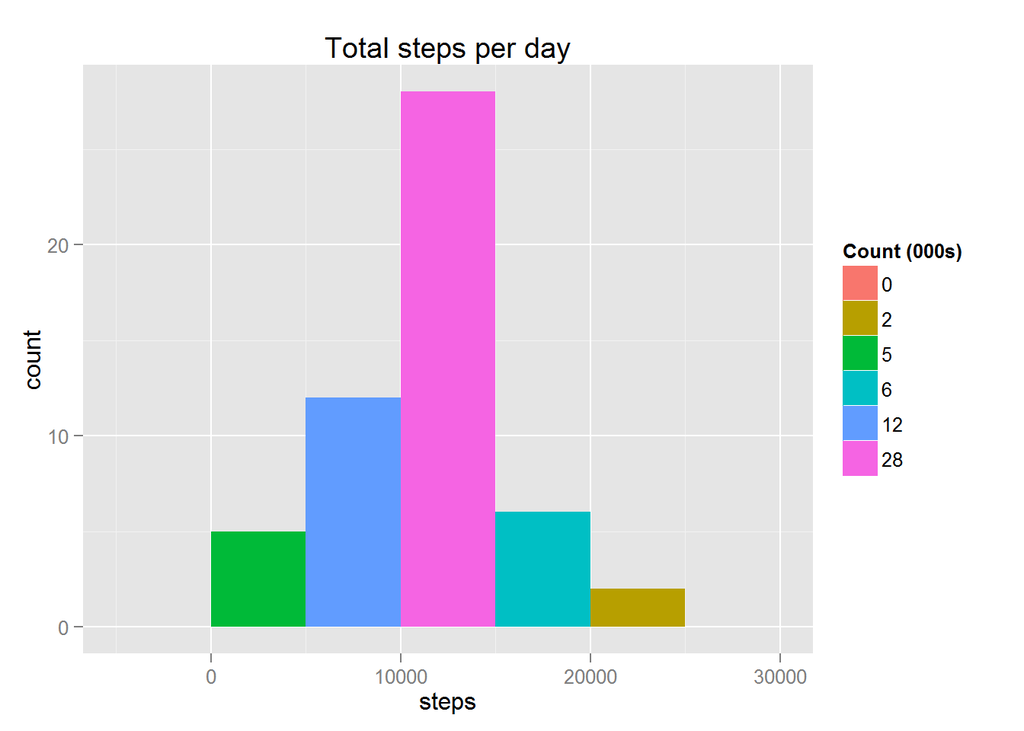

```r
require(ggplot2)
ggplot(TotalSteps, aes(steps)) + geom_histogram(binwidth = 5000, aes(fill = as.factor(..count..))) +
      labs(title = "Total steps per day") +
      guides(fill = guide_legend(title = "Count (000s)"))
```

2. Mean and median total number of steps taken per day

```r
mean(TotalSteps$steps)
```

```
## [1] 10766
```

```r
median(TotalSteps$steps)
```

```
## [1] 10765
```

## The average daily activity pattern?

1. A time series plot (i.e. type = “l”) of the 5-minute interval (x-axis) and the average number of steps taken, averaged across all days (y-axis)

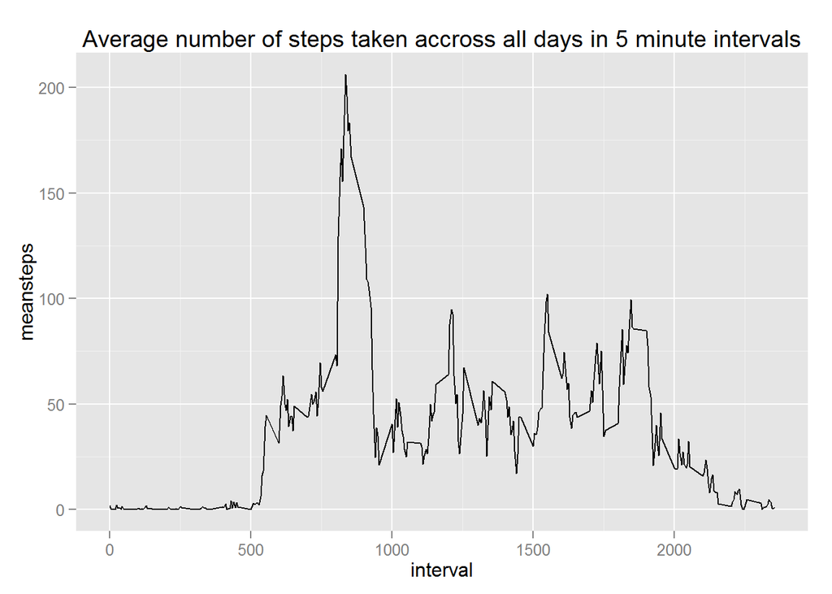

```r
library(plyr)
TimeSeries <- ddply(Activity, .(interval), summarize, meansteps = mean(steps))

ggplot(TimeSeries, aes(x=interval, y=meansteps)) + geom_line() +
      labs(title="Average number of steps taken accross all days in 5 minute intervals")
```

2. 5-minute interval, on average across all the days in the dataset, contains the maximum number of steps?

```r
max <- which.max(TimeSeries$meansteps)
TimeSeries$interval[max]
```

```
## [1] 835
```

## Imputing missing values

The total number of missing values in the dataset (i.e. the total number of rows with NAs) are imputed from the mean values for the same 5 minutes interval on all other days.

The new data set ActivityMerged after imputing NAs is obtain from the following code:

```r
ActivityMerged <- merge(activity, TimeSeries, by = "interval", all.x = T)
ActivityMerged <- ActivityMerged[with(ActivityMerged, order(date)), ]

for (i in 1:nrow(ActivityMerged)) {
      if (is.na(ActivityMerged$steps[i]) == T) {
            ActivityMerged$steps[i] <- ActivityMerged$meansteps[i]
      }
}
```

Histogram of the total number of steps taken each day

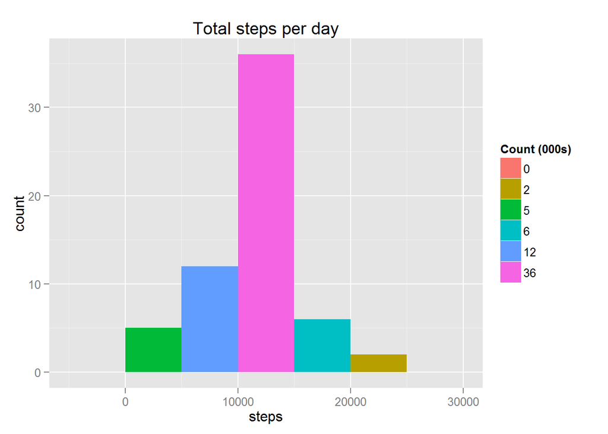

```r
TotalSteps2 <- aggregate(steps ~ date, data = ActivityMerged, sum)
ggplot(TotalSteps2, aes(steps)) + geom_histogram(binwidth = 5000, aes(fill = as.factor(..count..))) +
      labs(title = "Total steps per day") +
      guides(fill = guide_legend(title = "Count (000s)"))
```

Mean and median total number of steps taken per day

```r
mean(TotalSteps2$steps)
```

```
## [1] 10766
```

```r
median(TotalSteps2$steps)
```

```
## [1] 10766
```

After replacing missing values with mean values, only median changed a little bit.

## Are there differences in activity patterns between weekdays and weekends?

Creating a new factor variable in the dataset with two levels  “weekday” and “weekend” indicating whether a given date is a weekday or weekend day.

```r
ActivityMerged$wd <- weekdays(ActivityMerged$date)
ActivityMerged$WeekDay[ActivityMerged$wd == "Saturday" | ActivityMerged$wd == "Sunday"] <- "weekend"
ActivityMerged$WeekDay[is.na(ActivityMerged$WeekDay)] <- "weekday"
ActivityMerged$WeekDay <- as.factor(ActivityMerged$WeekDay)
```

A panel plot containing a time series plot (i.e. type = “l”) of the 5-minute interval (x-axis) and the average number of steps taken, averaged across all weekday days or weekend days (y-axis) is as following:

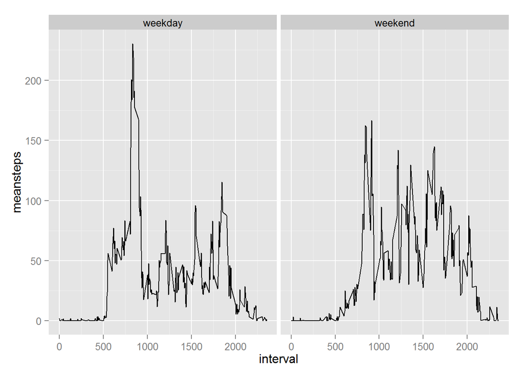

```r
TimeSeries2 <- ddply(ActivityMerged, .(WeekDay, interval), summarize, meansteps = mean(steps))
ggplot(TimeSeries2, aes(x=interval, y=meansteps)) + geom_line() + facet_wrap( ~ WeekDay )
```